[GitHub](https://github.com/JuliaGeometry/DelaunayTriangulation.jl)[](https://github.com/JuliaGeometry/DelaunayTriangulation.jl/tree/main/docs/src/literate_tutorials/convex.jl)

# Triangulating Convex Polygons

In this tutorial, we show how we can triangulate convex polygons. The function `triangulate_convex` is used for this. Let us start with a simple example.

```julia
using DelaunayTriangulation
using CairoMakie

points = [
    (10.0, 12.0), (7.0, 11.0), (8.0, 6.0),
    (10.0, 3.0), (14.0, 5.0), (15.0, 10.0),
    (13.0, 12.0)
]
S = 1:7
tri = triangulate_convex(points, 1:7)
```

```
Delaunay Triangulation.
   Number of vertices: 7
   Number of triangles: 5
   Number of edges: 11
   Has boundary nodes: false
   Has ghost triangles: true
   Curve-bounded: false
   Weighted: false
   Constrained: false
```

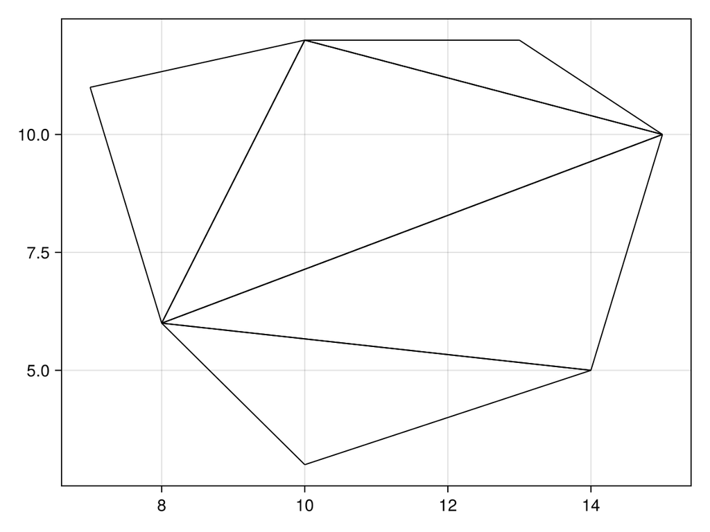

```julia
fig, ax, sc = triplot(tri)
fig
```

This `tri` is our triangulation of the convex polygon. The first input is the set of points, and `S` defines the vertices to take from these points and their order, which must be provided in a counter-clockwise order. Note that points does not have to contain only the points of the polygon, since `S` will be used to define the points needed.

Let us give a larger example. For simplicity, we triangulate a a discretised circle.

```julia
θ = LinRange(0, 2π, 5000) |> collect
pop!(θ)
x = cos.(θ)
y = sin.(θ)
points = tuple.(x, y)
S = 1:4999 # can also be [1:4999; 1], if you want the array to be circular
tri = triangulate_convex(points, S)
```

```
Delaunay Triangulation.
   Number of vertices: 4999
   Number of triangles: 4997
   Number of edges: 9995
   Has boundary nodes: false
   Has ghost triangles: true
   Curve-bounded: false
   Weighted: false
   Constrained: false
```

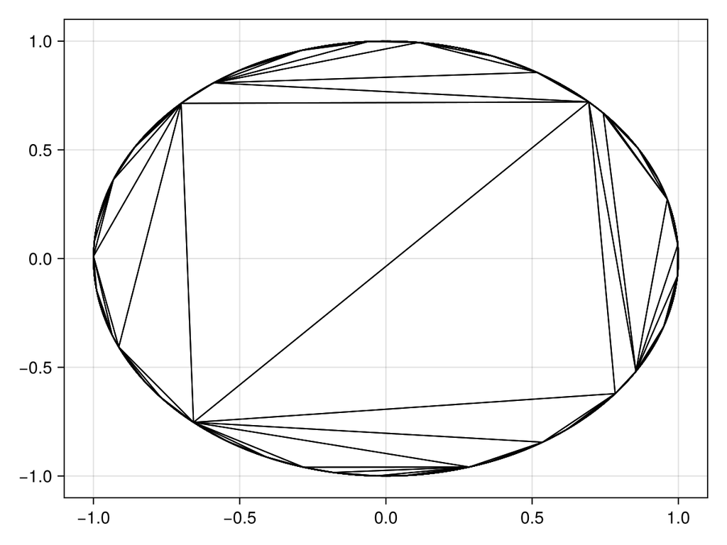

```julia
fig, ax, sc = triplot(tri)
fig
```

Here is a comparison of the time it takes to triangulate this using `triangulate_convex` or `triangulate`.

```julia
using BenchmarkTools
@benchmark triangulate_convex($points, $S)
```

```
BenchmarkTools.Trial: 80 samples with 1 evaluation.
 Range (min … max):  45.468 ms … 141.607 ms  ┊ GC (min … max):  0.00% … 32.57%
 Time  (median):     50.033 ms               ┊ GC (median):     0.00%
 Time  (mean ± σ):   62.868 ms ±  18.657 ms  ┊ GC (mean ± σ):  10.64% ± 10.03%

    ▂▆█
  ▃▇████▆▃▃▃▁▁▁▁▃▁▄▁▁▁▁▃▁▁▁▁▁▁▁▁▁▁▁▁▁▁▁▁▁▁▃▁▁▃▃█▄▄▁▃▆▃▆▄▄▃▃▆▁▃ ▁
  45.5 ms         Histogram: frequency by time         89.3 ms <

 Memory estimate: 30.20 MiB, allocs estimate: 576903.
```

```julia
@benchmark triangulate($points)
```

```
BenchmarkTools.Trial: 16 samples with 1 evaluation.
 Range (min … max):  308.327 ms … 381.460 ms  ┊ GC (min … max): 0.00% … 9.08%
 Time  (median):     321.234 ms               ┊ GC (median):    0.00%
 Time  (mean ± σ):   329.432 ms ±  20.419 ms  ┊ GC (mean ± σ):  1.83% ± 2.79%

  ▁  ▁ █▁ ▁▁█▁▁              █       ▁        ▁               ▁
  █▁▁█▁██▁█████▁▁▁▁▁▁▁▁▁▁▁▁▁▁█▁▁▁▁▁▁▁█▁▁▁▁▁▁▁▁█▁▁▁▁▁▁▁▁▁▁▁▁▁▁▁█ ▁
  308 ms           Histogram: frequency by time          381 ms <

 Memory estimate: 32.98 MiB, allocs estimate: 602773.
```

## Just the code

An uncommented version of this example is given below. You can view the source code for this file [here](https://github.com/JuliaGeometry/DelaunayTriangulation.jl/tree/main/docs/src/literate_tutorials/convex.jl).

```julia
using DelaunayTriangulation
using CairoMakie

points = [
    (10.0, 12.0), (7.0, 11.0), (8.0, 6.0),
    (10.0, 3.0), (14.0, 5.0), (15.0, 10.0),
    (13.0, 12.0)
]
S = 1:7
tri = triangulate_convex(points, 1:7)

fig, ax, sc = triplot(tri)
fig

θ = LinRange(0, 2π, 5000) |> collect
pop!(θ)
x = cos.(θ)
y = sin.(θ)
points = tuple.(x, y)
S = 1:4999 # can also be [1:4999; 1], if you want the array to be circular
tri = triangulate_convex(points, S)

fig, ax, sc = triplot(tri)
fig

using BenchmarkTools
@benchmark triangulate_convex($points, $S)

@benchmark triangulate($points)
```

*This page was generated using Literate.jl.*